# Partially observed functional data

Hyunsung Kim

2021-03-10

# Iteratively re-weighted least squares (IRLS; IRWLS)

## How to find the solution for robust regression

- The **M-estimator** for robust regression can be obtained from
  $$\hat{\beta} = \underset{\beta}{\operatorname{\arg\min}} \sum_{i=1}^n \rho \left( y_i - x_i^T\beta \right).$$
- The **scale-invariant M-estimator** is the following formula :
  $$\hat{\beta} = \arg\min_{\beta} \sum_{i=1}^n \rho \left( \frac{y_i - x_i^T\beta}{s} \right)$$
  where $s$ is a measure of the scale, and one of the estimate of $s$ is
  $$\hat{s} = 1.4826*\text{MAD}\left( \{ |y_i - x_i^T\beta| :i=1,\dots,n\} \right).$$
- Now, let $L = \sum_{i=1}^n \rho \left( \frac{y_i - x_i^T\beta}{s} \right)$, then a normal equation could be found by applying 1st derivative :
  $$\frac{\partial L}{\partial \beta} = \sum_{i=1}^n x_i \psi \left( \frac{y_i - x_i^T\beta}{s} \right) = 0, \text{ where } \psi(x) = \rho'(x)$$
- Set a weight $w_i = \psi \left( \frac{y_i - x_i^T\beta}{s} \right) / \left( y_i - x_i^T\beta \right)$, then a normal equation could be represented as
  $$\sum_{i=1}^n x_iw_i(y_i - x_i^T\beta) = 0 \\
  \Leftrightarrow X^TWY-XWX^T\beta=0$$
- Therefore, the solution can be obtained by weighted least squares (WLS) as
  $$\hat{\beta} = (X^TWX)^{-1}X^TWY$$
- To solve the above equation, we need to compute iteratively by following **Iteratively re-weighted least squares (IRLS) algorithm**.

## IRLS algorithm

1. Set initial value $\hat{\beta}^{(0)}$, then we can compute $W^{(0)}$.
2. Therefore, $\hat{\beta}^{(1)}$ for 1st iteration can be obtained as
   $$\hat{\beta}^{(1)} = (X^TW^{(0)}X)^{-1}X^TW^{(0)}Y.$$
3. Similarly, $\hat{\beta}^{(t+1)}$ for $t$th iterations can be represented as
   $$\hat{\beta}^{(t+1)} = (X^TW^{(t)}X)^{-1}X^TW^{(t)}Y.$$
4. Repeat this procedure until $\hat{\beta}^{(t)}$ is converged.

## IRLS for local kernel smoother with robust loss function

- The **M-estimator** of local polynomial smoother can be obtained from
  $$(\hat{b}_0, \hat{b}_1) = \underset{(b_0,b_1) \in \mathbb{R}^2}{\operatorname{\arg\min}} \sum_{i=1}^n w_i \sum_{j=1}^{m_i} K_{h_{\mu}} (T_{ij}-t) \rho \left\{ Y_{ij} - b_0 - b_1(T_{ij}-t) \right\}.$$
- The **scale-invariant M-estimator** is the following formula :
  $$(\hat{b}_0, \hat{b}_1) = \underset{(b_0,b_1) \in \mathbb{R}^2}{\operatorname{\arg\min}} \sum_{i=1}^n w_i \sum_{j=1}^{m_i} K_{h_{\mu}} (T_{ij}-t) \rho \left\{ \frac{Y_{ij} - b_0 - b_1(T_{ij}-t)}{s} \right\}.$$
- Let $x_{ij} = (1, T_{ij}-t)^T$ and $\beta = (b_0, b_1)^T$.
- Let $L = \sum_{i=1}^n w_i \sum_{j=1}^{m_i} K_{h_{\mu}} (T_{ij}-t) \rho \left( \frac{Y_{ij} - x_{ij}^T \beta}{s} \right)$, then we could find the solution $\hat{\beta} = \arg\min_{\beta} L$.
- Normal equation :
  $$\frac{\partial L}{\partial \beta} = \sum_{i=1}^n w_i \sum_{j=1}^{m_i} K_{h_{\mu}} (T_{ij}-t) x_{ij} \psi \left( Y_{ij} - x_{ij}^T \beta \right) = 0$$
- Set $w_i = \left\{ w_i K_{h_{\mu}} (T_{ij}-t) \psi \left( \frac{Y_{ij} - x_{ij}^T \beta}{s} \right) \right\} / \left( Y_{ij} - x_{ij}^T \beta \right).$
- Apply **IRLS algorithm** until $\hat{\beta}$ is converged.

# Selection $\delta$ for Huber loss

$$\rho(x) =
\begin{cases}
\frac{x^2}{2}, & \mbox{if } |x| \le \delta \\
\delta(|x|-\frac{1}{2}\delta), & \mbox{if } |x| > \delta
\end{cases}$$

## Naive method

$$\delta = 1 / \max\left\{ |Y_{ij}| : i = 1,\dots,n, j = 1,\dots,m_i \right\}$$

## Cross-validation

- CV error 계산에서는 Huber loss 보다는 $L_1$ loss를 사용하는 것이 나을 것으로 생각됨. (여기서도 $\delta$에 depend하기 때문)

## Data-adaptive method

> - Sun, Q., Zhou, W. X., & Fan, J. (2020). [Adaptive huber regression](https://doi.org/10.1080/01621459.2018.1543124). Journal of the American Statistical Association, 115(529), 254-265.
> - Wang, L., Zheng, C., Zhou, W., & Zhou, W. X. (2020). [A new principle for tuning-free Huber regression](https://eprints.soton.ac.uk/441508/1/SS_2019_0045_na.pdf). Statistica Sinica.

# Variance trajectories between different robustness parameters in Huber function and bandwidths

- Estimated variance $\hat{\sigma}_X^2$은 median based estimator $\hat{\sigma}_0^2$를 모두 빼준 값임.
- Huber function의 cutoff parameter $\delta$에 따라 형태가 매우 달라짐.
- 전체적으로 bandwidth는 smoothness에만 영향을 주고, trajectory의 형태에는 큰 영향을 미치지는 않음.
- WRM은 Huber loss를 사용한 경우에 비해 under estimate되는 경향이 보임.

## 1st simulation data

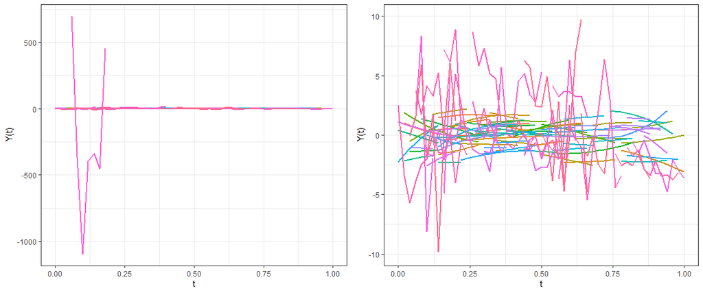

Figure 1. Sample curves for 1st simulation data.

### $\delta$ in Huber function

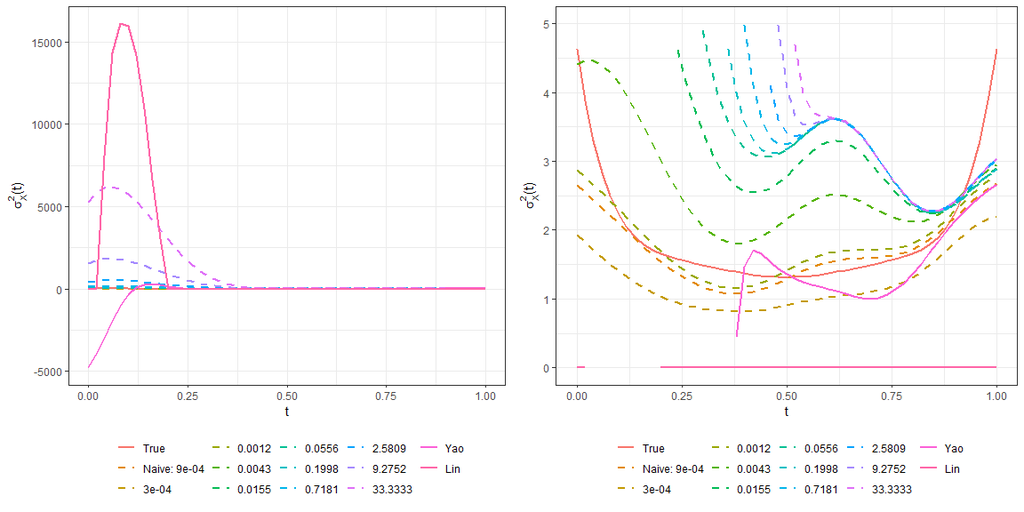

Figure 2. Trajectories of true and estimated variances with different robustness parameter $\delta$.

### Bandwidth for local kernel smoother and WRM with $\delta = 0.0009$

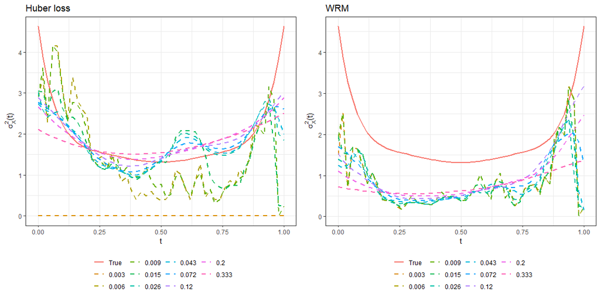

Figure 3. Trajectories of true and estimated variances with different bandwidths.

## 20th simulation data

### $\delta$ in Huber function

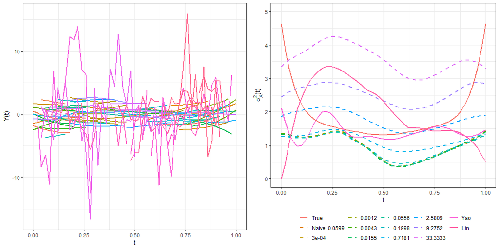

Figure 4. Sample curves for 20th simulation data and trajectories of true and estimated variances with different robustness parameter $\delta$.

### Bandwidth for local kernel smoother and WRM with $\delta = 2.5809$

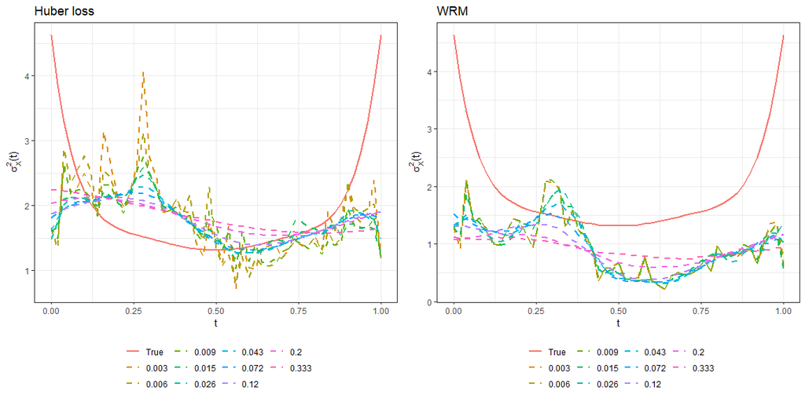

Figure 5. Trajectories of true and estimated variances with different bandwidths.